# Estimating causal effects with propensity scores

## Cohort: new users of Cox-2 inhibitors versus Non-selective NSAID in the National Ambulatory Medical Care Data Survey

We have built a cohort from the 2005-2009 public use files from National Ambulatory Medical Care Data Survey (NAMCS). The NAMCS survey covers over 20,000 visits per year and includes data on patient demographics, comorbidities, physician and practice characteristics, and treatment received, including medications. Currently, medications are classified using the Multum Lexicon.

From these data, we identified new users of either NSAID or Cox-2 selective non-steroidal anti-inflammatory drugs (NSAIDs). The data were augmented with a simulated peptic ulcer disease outcome. Variables were selected for this extract based on relevance to the example analyses and on availability for most or all of the 2005-2009 time range.

## Viewing the data

It is always important to review new data. In the $\tt{NAMCS}$ package, the data frame is named $\tt{ns}$. To browse the data, we pipe the data frame $\tt{ns}$ into the $\tt{datatable}$ function, which creates an interactive viewer in the output.

```r
ns %>% datatable()
```

|  | year | region | age | arthritis | asthma | cancer | cerebrovascular_disease | chronic_kidney_disease | heart_failure | chronic_pulmonary_disease | depression | diabetes | hyperlipidemia | hypertension | coronory_artery_disease | osteoporosis | cox2_initiation | anti_hypertensive_use | statin_use | h2_antagonist_use | ppi_use | aspirin_use | anti_coagulant_use | corticosteroid_use | sex | race | incident_pud |
| --- | --- | --- | --- | --- | --- | --- | --- | --- | --- | --- | --- | --- | --- | --- | --- | --- | --- | --- | --- | --- | --- | --- | --- | --- | --- | --- | --- |
| 1 | 2005 | Northeast | 44 | No | No | No | No | No | No | No | No | No | No | No | No | No | No | No | No | No | No | No | No | No | Male | White | No |
| 2 | 2005 | Northeast | 58 | No | No | No | No | No | No | No | No | No | No | No | No | No | Yes | No | No | No | No | No | No | No | Female | White | No |
| 3 | 2005 | Northeast | 78 | No | No | No | No | No | No | No | No | No | No | No | No | No | No | No | No | No | No | No | No | No | Female | White | Yes |
| 4 | 2005 | Northeast | 23 | No | No | No | No | No | No | No | No | No | No | No | No | No | No | No | No | No | No | No | No | No | Male | White | No |
| 5 | 2005 | Northeast | 56 | Yes | No | No | No | No | No | No | No | No | No | No | No | No | No | No | No | No | No | No | No | No | Male | White | No |
| 6 | 2005 | Northeast | 68 | Yes | No | No | No | No | No | No | No | Yes | No | No | No | No | No | No | No | No | Yes | No | No | No | Female | White | No |
| 7 | 2005 | Northeast | 46 | No | No | No | No | No | No | No | No | Yes | No | No | No | No | No | Yes | No | No | No | No | No | No | Female | White | Yes |
| 8 | 2005 | Northeast | 40 | No | No | Yes | No | No | No | No | No | No | No | No | No | No | No | No | No | No | No | No | No | No | Female | White | No |
| 9 | 2005 | Northeast | 29 | Yes | Yes | No | No | No | No | No | No | No | No | No | No | No | No | No | No | Yes | No | No | No | No | Male | White | No |
| 10 | 2005 | Northeast | 61 | Yes | No | No | No | No | No | No | No | Yes | Yes | Yes | No | No | No | Yes | No | No | No | Yes | No | No | Male | White | No |

[output cut: 2872 more lines]

## Create a simple Table 1

To understand the characteristics of each treatment group, we create a table 1 summarizing variables by treatment group. Variables with an SMD > 0.1 are customarily considered to be out of balance. The table suggest that the Cox-2 selective NSAID initiators are older and have a higher burden of comorbid conditions that the patients starting non-selective NSAIDs.

```r
factor_vars = c("year", "region", "arthritis", "asthma", "cancer", "cerebrovascular_disease", "chronic_kidney_disease", "heart_failure", "chronic_pulmonary_disease", "depression", "diabetes", "hyperlipidemia", "hypertension", "coronory_artery_disease", "osteoporosis",  "anti_hypertensive_use", "statin_use", "h2_antagonist_use", "ppi_use", "aspirin_use", "anti_coagulant_use", "corticosteroid_use", "sex", "race", "incident_pud")

table1 = CreateTableOne(data = ns, vars = c("age", factor_vars), factorVars = factor_vars,
                        strata = "cox2_initiation", test = FALSE, smd = TRUE)

print(table1, smd = TRUE, printToggle = FALSE) %>% kable()
```

|  | No | Yes | SMD |
| --- | --- | --- | --- |
| n | 2642 | 240 |  |
| age (mean (SD)) | 47.30 (16.64) | 53.43 (15.72) | 0.379 |
| year (%) |  |  | 0.283 |
| 2005 | 411 (15.6) | 57 (23.8) |  |
| 2006 | 573 (21.7) | 52 (21.7) |  |
| 2007 | 554 (21.0) | 47 (19.6) |  |
| 2008 | 498 (18.8) | 50 (20.8) |  |
| 2009 | 606 (22.9) | 34 (14.2) |  |
| region (%) |  |  | 0.145 |
| Northeast | 455 (17.2) | 34 (14.2) |  |
| Midwest | 588 (22.3) | 51 (21.2) |  |
| South | 978 (37.0) | 105 (43.8) |  |
| West | 621 (23.5) | 50 (20.8) |  |
| arthritis = Yes (%) | 793 (30.0) | 112 (46.7) | 0.348 |
| asthma = Yes (%) | 111 ( 4.2) | 11 ( 4.6) | 0.019 |
| cancer = Yes (%) | 82 ( 3.1) | 5 ( 2.1) | 0.064 |
| cerebrovascular_disease = Yes (%) | 31 ( 1.2) | 6 ( 2.5) | 0.099 |
| chronic_kidney_disease = Yes (%) | 14 ( 0.5) | 2 ( 0.8) | 0.037 |
| heart_failure = Yes (%) | 13 ( 0.5) | 1 ( 0.4) | 0.011 |
| chronic_pulmonary_disease = Yes (%) | 59 ( 2.2) | 7 ( 2.9) | 0.043 |
| depression = Yes (%) | 237 ( 9.0) | 27 (11.2) | 0.076 |
| diabetes = Yes (%) | 215 ( 8.1) | 31 (12.9) | 0.156 |
| hyperlipidemia = Yes (%) | 344 (13.0) | 39 (16.2) | 0.091 |
| hypertension = Yes (%) | 605 (22.9) | 71 (29.6) | 0.152 |
| coronory_artery_disease = Yes (%) | 52 ( 2.0) | 4 ( 1.7) | 0.023 |
| osteoporosis = Yes (%) | 62 ( 2.3) | 13 ( 5.4) | 0.159 |
| anti_hypertensive_use = Yes (%) | 169 ( 6.4) | 20 ( 8.3) | 0.074 |
| statin_use = Yes (%) | 137 ( 5.2) | 20 ( 8.3) | 0.126 |
| h2_antagonist_use = Yes (%) | 28 ( 1.1) | 5 ( 2.1) | 0.082 |
| ppi_use = Yes (%) | 80 ( 3.0) | 11 ( 4.6) | 0.081 |
| aspirin_use = Yes (%) | 83 ( 3.1) | 9 ( 3.8) | 0.033 |
| anti_coagulant_use = Yes (%) | 9 ( 0.3) | 2 ( 0.8) | 0.065 |
| corticosteroid_use = Yes (%) | 13 ( 0.5) | 5 ( 2.1) | 0.141 |
| sex = Male (%) | 1090 (41.3) | 100 (41.7) | 0.008 |
| race (%) |  |  | 0.080 |
| White | 2082 (78.8) | 193 (80.4) |  |
| Black | 409 (15.5) | 31 (12.9) |  |
| Other | 151 ( 5.7) | 16 ( 6.7) |  |
| incident_pud = Yes (%) | 258 ( 9.8) | 30 (12.5) | 0.087 |

## Fit a propensity score model and display parameter estimates

A logistic regression can be used to estimate the propensity scores using the $\tt{glm}$ function. The parameter estimates from the fitted model are generated using the $\tt{summary}$ function. The estimates are log odds ratios (ORs). Exponentiating the ORs gives approximate risk ratios (because Cox-2 treatment) is rare. We include in the PS models the variables that we know are predictors of the outcome and thus potentially true confounders.

```r
ps_model = glm(cox2_initiation ~ age + race + sex + arthritis + aspirin_use + anti_coagulant_use + corticosteroid_use + arthritis, data = ns, family = binomial)

summary(ps_model)
```

```
##
## Call:
## glm(formula = cox2_initiation ~ age + race + sex + arthritis +
##     aspirin_use + anti_coagulant_use + corticosteroid_use + arthritis,
##     family = binomial, data = ns)
##
## Coefficients:
##                        Estimate Std. Error z value Pr(>|z|)
## (Intercept)           -3.510066   0.237499 -14.779  < 2e-16 ***
## age                    0.017677   0.004189   4.220 2.44e-05 ***
## raceBlack             -0.154477   0.203747  -0.758   0.4483
## raceOther              0.115297   0.277459   0.416   0.6777
## sexMale                0.016765   0.138530   0.121   0.9037
## arthritisYes           0.563201   0.140529   4.008 6.13e-05 ***
## aspirin_useYes        -0.128728   0.364830  -0.353   0.7242
## anti_coagulant_useYes  0.645528   0.792982   0.814   0.4156
## corticosteroid_useYes  1.395617   0.538087   2.594   0.0095 **
## ---
## Signif. codes:  0 '***' 0.001 '**' 0.01 '*' 0.05 '.' 0.1 ' ' 1
##
## (Dispersion parameter for binomial family taken to be 1)
##
##     Null deviance: 1652.5  on 2881  degrees of freedom
## Residual deviance: 1600.5  on 2873  degrees of freedom
## AIC: 1618.5
##
## Number of Fisher Scoring iterations: 5
```

```r
tidy(ps_model, exponentiate = TRUE, conf.int = TRUE) %>% kable()
```

| term | estimate | std.error | statistic | p.value | conf.low | conf.high |
| --- | --- | --- | --- | --- | --- | --- |
| (Intercept) | 0.0298949 | 0.2374988 | -14.7793023 | 0.0000000 | 0.0186097 | 0.0472379 |
| age | 1.0178341 | 0.0041886 | 4.2202130 | 0.0000244 | 1.0095105 | 1.0262335 |
| raceBlack | 0.8568629 | 0.2037468 | -0.7581830 | 0.4483414 | 0.5650775 | 1.2592301 |
| raceOther | 1.1222071 | 0.2774592 | 0.4155473 | 0.6777413 | 0.6284496 | 1.8776266 |
| sexMale | 1.0169067 | 0.1385300 | 0.1210231 | 0.9036728 | 0.7736373 | 1.3324319 |
| arthritisYes | 1.7562846 | 0.1405287 | 4.0077269 | 0.0000613 | 1.3321740 | 2.3122849 |
| aspirin_useYes | 0.8792132 | 0.3648303 | -0.3528431 | 0.7242061 | 0.4017730 | 1.7063943 |
| anti_coagulant_useYes | 1.9069941 | 0.7929821 | 0.8140515 | 0.4156154 | 0.2865549 | 7.6015716 |
| corticosteroid_useYes | 4.0374652 | 0.5380870 | 2.5936646 | 0.0094959 | 1.2710282 | 10.9836784 |

## Add the propensity score to a new analytic data set

The $\tt{predict}$ function generates predicted probabilities (the estimated PSs) from the fitted PS model. These can be added back into the analytic file. Here we make a new dataset that includes the original data and the estimated PSs.

```r
ns_analy <- ns
#ns_analy$ps <- predict(ps_model, type = "response")
ns_analy = ns %>% mutate(ps = predict(ps_model, type = "response"))
```

## Plot the distribution of PS, by treatment group

The PS distribution can be plotted by treatment group to determine whether there is substantial non-overlap in the PS distributions, suggesting problems with positivity. Here there do not appear to be problems.

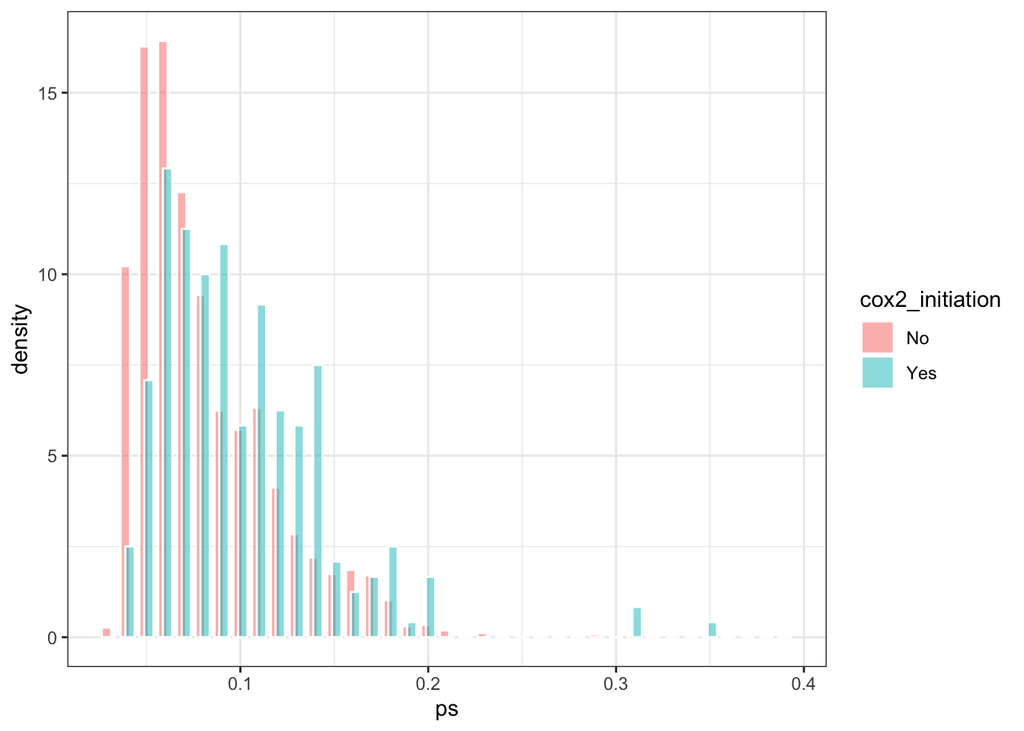

```r
ggplot(data = ns_analy, aes(x = ps, group = cox2_initiation, fill = cox2_initiation)) +
  geom_histogram(
    aes(y = ..density..),
    color = "white",
    alpha = 0.5,
    binwidth = 0.01,
    position = position_dodge(width = 0.01/2)) + theme_bw() +
  guides(colour = FALSE,
         linetype = FALSE)
```

## Fit a logistic regression of the outcome

We can fit a simple logistic model of the outcome on treatment to compute an unadjusted estimate of the effect of treatment on the outcome. Here we see the Cox-2 use is associated with a slightly increased risk, that is indistinguishable from the null. We know that this is biased due to confounding since we simulated the outcome.

```r
glm_unweighted = glm(incident_pud ~ cox2_initiation, data = ns_analy, family = binomial)
summary(glm_unweighted)
```

```
##
## Call:
## glm(formula = incident_pud ~ cox2_initiation, family = binomial,
##     data = ns_analy)
##
## Coefficients:
##                    Estimate Std. Error z value Pr(>|z|)
## (Intercept)        -2.22358    0.06553 -33.931   <2e-16 ***
## cox2_initiationYes  0.27767    0.20589   1.349    0.177
## ---
## Signif. codes:  0 '***' 0.001 '**' 0.01 '*' 0.05 '.' 0.1 ' ' 1
##
## (Dispersion parameter for binomial family taken to be 1)
##
##     Null deviance: 1872.9  on 2881  degrees of freedom
## Residual deviance: 1871.2  on 2880  degrees of freedom
## AIC: 1875.2
##
## Number of Fisher Scoring iterations: 4
```

```r
tidy(glm_unweighted)
```

```
## # A tibble: 2 × 5
##   term               estimate std.error statistic   p.value
##   <chr>                 <dbl>     <dbl>     <dbl>     <dbl>
## 1 (Intercept)          -2.22     0.0655    -33.9  2.34e-252
## 2 cox2_initiationYes    0.278    0.206       1.35 1.77e-  1
```

## Compute IPTW

Now we can add to the data the inverse probability of treatment weights (IPTWs)

```r
# ns_analy$iptw = I(ns_analy[["cox2_initiation"]] == "Yes") / ns_analy$ps +
#   (I(ns_analy[["cox2_initiation"]] == "No")) / (1 - ns_analy$ps)

ns_analy <- ns_analy %>% mutate(iptw = ifelse(cox2_initiation == "Yes", 1/ps, 1/(1-ps)))
```

## Summarize weights by treatment groups

We inspect the distribution of weights within each treatment group to look for unusually small or large weights that reflect highly influential observations which should be examined to rule out problems with data.

```r
summary(ns_analy$iptw[ns_analy$cox2_initiation == "Yes"],)
```

```
##    Min. 1st Qu.  Median    Mean 3rd Qu.    Max.
##   2.827   8.193  10.798  11.758  14.633  28.413
```

```r
ns_analy %>% filter(cox2_initiation == "Yes") %>% pull(iptw) %>% summary()
```

```
##    Min. 1st Qu.  Median    Mean 3rd Qu.    Max.
##   2.827   8.193  10.798  11.758  14.633  28.413
```

```r
summary(ns_analy$iptw[ns_analy$cox2_initiation == "No"],)
```

```
##    Min. 1st Qu.  Median    Mean 3rd Qu.    Max.
##   1.035   1.057   1.075   1.091   1.114   1.628
```

## Create weighted table 1

To determine if the IPTWs have appropriately balanced covariates, we can construct a weighted Table 1. We see that the variables included in the PS model appear to be well balanced.

```r
ns.svy = svydesign(ids = ~ 1, data = ns_analy,
                   weights = ~ iptw)

ipw_table1 = svyCreateTableOne(vars = factor_vars, factorVars = factor_vars,
                  strata = "cox2_initiation",
                  data = ns.svy, test = FALSE, smd = TRUE)

print(ipw_table1, smd = TRUE)
```

```
##                                      Stratified by cox2_initiation
##                                       No             Yes            SMD
##   n                                   2882.7         2822.0
##   year (%)                                                           0.339
##      2005                              452.9 (15.7)   687.3 (24.4)
##      2006                              625.4 (21.7)   628.1 (22.3)
##      2007                              604.4 (21.0)   536.2 (19.0)
##      2008                              540.4 (18.7)   628.9 (22.3)
##      2009                              659.7 (22.9)   341.6 (12.1)
##   region (%)                                                         0.135
##      Northeast                         496.5 (17.2)   403.7 (14.3)
##      Midwest                           639.5 (22.2)   588.6 (20.9)
##      South                            1069.6 (37.1)  1225.5 (43.4)
##      West                              677.0 (23.5)   604.4 (21.4)
##   arthritis = Yes (%)                  906.6 (31.5)   956.4 (33.9)   0.052
##   asthma = Yes (%)                     121.8 ( 4.2)   149.9 ( 5.3)   0.051
##   cancer = Yes (%)                      91.3 ( 3.2)    59.9 ( 2.1)   0.065
##   cerebrovascular_disease = Yes (%)     35.0 ( 1.2)    44.9 ( 1.6)   0.032
##   chronic_kidney_disease = Yes (%)      16.0 ( 0.6)    21.6 ( 0.8)   0.026
##   heart_failure = Yes (%)               15.1 ( 0.5)     9.2 ( 0.3)   0.030
##   chronic_pulmonary_disease = Yes (%)   65.3 ( 2.3)    65.6 ( 2.3)   0.004
##   depression = Yes (%)                 258.8 ( 9.0)   348.4 (12.3)   0.109
##   diabetes = Yes (%)                   239.6 ( 8.3)   366.8 (13.0)   0.152
##   hyperlipidemia = Yes (%)             384.4 (13.3)   409.6 (14.5)   0.034
##   hypertension = Yes (%)               674.9 (23.4)   755.3 (26.8)   0.077
##   coronory_artery_disease = Yes (%)     59.0 ( 2.0)    36.0 ( 1.3)   0.060
##   osteoporosis = Yes (%)                71.3 ( 2.5)   106.7 ( 3.8)   0.075
##   anti_hypertensive_use = Yes (%)      188.4 ( 6.5)   203.5 ( 7.2)   0.027
##   statin_use = Yes (%)                 154.5 ( 5.4)   214.7 ( 7.6)   0.091
##   h2_antagonist_use = Yes (%)           31.1 ( 1.1)    55.4 ( 2.0)   0.072
##   ppi_use = Yes (%)                     89.2 ( 3.1)   108.1 ( 3.8)   0.040
##   aspirin_use = Yes (%)                 91.6 ( 3.2)    76.6 ( 2.7)   0.027
##   anti_coagulant_use = Yes (%)          11.1 ( 0.4)    11.5 ( 0.4)   0.004
##   corticosteroid_use = Yes (%)          18.2 ( 0.6)    19.2 ( 0.7)   0.006
##   sex = Male (%)                      1190.7 (41.3)  1183.7 (41.9)   0.013
##   race (%)                                                           0.025
##      White                            2275.4 (78.9)  2236.6 (79.3)
##      Black                             440.2 (15.3)   410.4 (14.5)
##      Other                             167.1 ( 5.8)   175.1 ( 6.2)
##   incident_pud = Yes (%)               294.5 (10.2)   265.1 ( 9.4)   0.028
```

## Estimate IPTW regression of outcome on treatment

We can now estimate the causal effect of treatment on the outcome risk by doing a weighted regression.

```r
glm_weighted = glm(incident_pud ~ cox2_initiation, data = ns_analy, family = binomial,
                     weights = iptw)
summary(glm_weighted)
```

```
##
## Call:
## glm(formula = incident_pud ~ cox2_initiation, family = binomial,
##     data = ns_analy, weights = iptw)
##
## Coefficients:
##                    Estimate Std. Error z value Pr(>|z|)
## (Intercept)        -2.17338    0.06150 -35.342   <2e-16 ***
## cox2_initiationYes -0.09317    0.08914  -1.045    0.296
## ---
## Signif. codes:  0 '***' 0.001 '**' 0.01 '*' 0.05 '.' 0.1 ' ' 1
##
## (Dispersion parameter for binomial family taken to be 1)
##
##     Null deviance: 3661.0  on 2881  degrees of freedom
## Residual deviance: 3659.9  on 2880  degrees of freedom
## AIC: 3462.7
##
## Number of Fisher Scoring iterations: 6
```

## Compute SMRW

We can also add to the data set a standardized mortality ratio weight, which standardizes the distribution of covariates to the treated population. In an SMRW regression, the estimates can be interpreted as the average effect of treatment among the treated (here the Cox-2 group).

```r
ns_analy$smrw= I(ns[["cox2_initiation"]] == "Yes") +
  (1 - I(ns[["cox2_initiation"]] == "Yes")) * ns_analy$ps / (1-ns_analy$ps)
```

## Summarize weights by treatment groups

We inspect the distribution of weights within each treatment group to look for unusually small or large weights that reflect highly influential observations that should be examined to rule out problems with data. All weights in the Cox-2 group are 1, as required.

```r
summary(ns_analy$smrw[ns_analy$cox2_initiation == "Yes"],)
```

```
##    Min. 1st Qu.  Median    Mean 3rd Qu.    Max.
##       1       1       1       1       1       1
```

```r
summary(ns_analy$smrw[ns_analy$cox2_initiation == "No"],)
```

```
##    Min. 1st Qu.  Median    Mean 3rd Qu.    Max.
## 0.03521 0.05675 0.07496 0.09111 0.11390 0.62837
```

## Compute weighted table 1

To determine if the SMRWs have appropriately balanced covariates, we can construct a weighted Table 1. Here we see that the covariates in the NSAID group that were included in the PS model have a similar mean to those in the Cox-2 group.

```r
ns.svy = svydesign(ids = ~ 1, data = ns_analy,
                   weights = ~ smrw)

smrw_table1 = ipw_table1 = svyCreateTableOne(vars = factor_vars, factorVars = factor_vars,
                  strata = "cox2_initiation",
                  data = ns.svy, test = FALSE, smd = TRUE)


print(smrw_table1, smd = TRUE)
```

```
##                                      Stratified by cox2_initiation
##                                       No            Yes           SMD
##   n                                   240.7         240.0
##   year (%)                                                         0.252
##      2005                              41.9 (17.4)   57.0 (23.8)
##      2006                              52.4 (21.7)   52.0 (21.7)
##      2007                              50.4 (20.9)   47.0 (19.6)
##      2008                              42.4 (17.6)   50.0 (20.8)
##      2009                              53.7 (22.3)   34.0 (14.2)
##   region (%)                                                       0.129
##      Northeast                         41.5 (17.3)   34.0 (14.2)
##      Midwest                           51.5 (21.4)   51.0 (21.2)
##      South                             91.6 (38.1)  105.0 (43.8)
##      West                              56.0 (23.3)   50.0 (20.8)
##   arthritis = Yes (%)                 113.6 (47.2)  112.0 (46.7)   0.011
##   asthma = Yes (%)                     10.8 ( 4.5)   11.0 ( 4.6)   0.005
##   cancer = Yes (%)                      9.3 ( 3.9)    5.0 ( 2.1)   0.105
##   cerebrovascular_disease = Yes (%)     4.0 ( 1.6)    6.0 ( 2.5)   0.060
##   chronic_kidney_disease = Yes (%)      2.0 ( 0.8)    2.0 ( 0.8)  <0.001
##   heart_failure = Yes (%)               2.1 ( 0.9)    1.0 ( 0.4)   0.058
##   chronic_pulmonary_disease = Yes (%)   6.3 ( 2.6)    7.0 ( 2.9)   0.017
##   depression = Yes (%)                 21.8 ( 9.1)   27.0 (11.2)   0.073
##   diabetes = Yes (%)                   24.6 (10.2)   31.0 (12.9)   0.085
##   hyperlipidemia = Yes (%)             40.4 (16.8)   39.0 (16.2)   0.015
##   hypertension = Yes (%)               69.9 (29.0)   71.0 (29.6)   0.012
##   coronory_artery_disease = Yes (%)     7.0 ( 2.9)    4.0 ( 1.7)   0.083
##   osteoporosis = Yes (%)                9.3 ( 3.9)   13.0 ( 5.4)   0.073
##   anti_hypertensive_use = Yes (%)      19.4 ( 8.1)   20.0 ( 8.3)   0.010
##   statin_use = Yes (%)                 17.5 ( 7.3)   20.0 ( 8.3)   0.039
##   h2_antagonist_use = Yes (%)           3.1 ( 1.3)    5.0 ( 2.1)   0.063
##   ppi_use = Yes (%)                     9.2 ( 3.8)   11.0 ( 4.6)   0.038
##   aspirin_use = Yes (%)                 8.6 ( 3.6)    9.0 ( 3.8)   0.010
##   anti_coagulant_use = Yes (%)          2.1 ( 0.9)    2.0 ( 0.8)   0.003
##   corticosteroid_use = Yes (%)          5.2 ( 2.1)    5.0 ( 2.1)   0.004
##   sex = Male (%)                      100.7 (41.8)  100.0 (41.7)   0.003
##   race (%)                                                         0.002
##      White                            193.4 (80.4)  193.0 (80.4)
##      Black                             31.2 (12.9)   31.0 (12.9)
##      Other                             16.1 ( 6.7)   16.0 ( 6.7)
##   incident_pud = Yes (%)               36.5 (15.2)   30.0 (12.5)   0.077
```

## Estimate an SMRW regression of the outcome on treatment

Finally, we can perform a weighted regression of the outcome on treatment, with the SMRWs, to estimate the average effect of treatment in the treated.

```r
glm_weighted = glm(incident_pud ~ cox2_initiation, data = ns_analy, family = binomial,
                   weights = smrw)
summary(glm_weighted)
```

```
##
## Call:
## glm(formula = incident_pud ~ cox2_initiation, family = binomial,
##     data = ns_analy, weights = smrw)
##
## Coefficients:
##                    Estimate Std. Error z value Pr(>|z|)
## (Intercept)         -1.7213     0.1797  -9.581   <2e-16 ***
## cox2_initiationYes  -0.2246     0.2653  -0.847    0.397
## ---
## Signif. codes:  0 '***' 0.001 '**' 0.01 '*' 0.05 '.' 0.1 ' ' 1
##
## (Dispersion parameter for binomial family taken to be 1)
##
##     Null deviance: 386.49  on 2881  degrees of freedom
## Residual deviance: 385.77  on 2880  degrees of freedom
## AIC: 192.72
##
## Number of Fisher Scoring iterations: 4
```

## Getting correct confidence intervals for IPTW / SMRW estimates

To get correct confidence intervals for the PS weighted regressions, you need to use a generalized estimating equation (GEE) approach that provides a robust estimator of the standard error. To use the GEE function in the $\tt{geepack}$ library, some minor modifications to the underlying data are needed – we need to create a subject identifier and change the outcome to a numeric variable.

```r
ns_analy$.id = seq(1, nrow(ns_analy))
ns_analy$y = ifelse(ns$incident_pud == "Yes", 1, 0)
gee_weighted = geeglm(y ~ cox2_initiation, data = ns_analy, weights = smrw, id=.id, family = binomial)
summary(gee_weighted)
```

```
##
## Call:
## geeglm(formula = y ~ cox2_initiation, family = binomial, data = ns_analy,
##     weights = smrw, id = .id)
##
##  Coefficients:
##                    Estimate  Std.err    Wald Pr(>|W|)
## (Intercept)        -1.72131  0.07316 553.604   <2e-16 ***
## cox2_initiationYes -0.22460  0.20844   1.161    0.281
## ---
## Signif. codes:  0 '***' 0.001 '**' 0.01 '*' 0.05 '.' 0.1 ' ' 1
##
## Correlation structure = independence
## Estimated Scale Parameters:
##
##             Estimate Std.err
## (Intercept)        1  0.1548
## Number of clusters:   2882  Maximum cluster size: 1
```